# Never get an Uber on a Thursday!

Helene LvS

2024-03-11

I recently requested my trip data from Uber. Unfortunately it didn’t include the whole list of trips, but at least the results included trips across countries of the EMEA region.

I didn’t know what I wanted to do with the data except maybe just compare the different experiences across the three regions I had exposure in.

So, here is my anecdotal analysis of my Uber trips and the bottom line:

*If you’re me, never get an Uber on a Thursday…*

## High Level Exploratory Data Analysis

### Trip counts

Data for 37 of my Uber trips were available; 29 of which completed successfully. There were 8 incidents where the trip was not completed successfully.

- None of the unsuccessful trips occurred in Africa
- All of them occurred on a Thursday

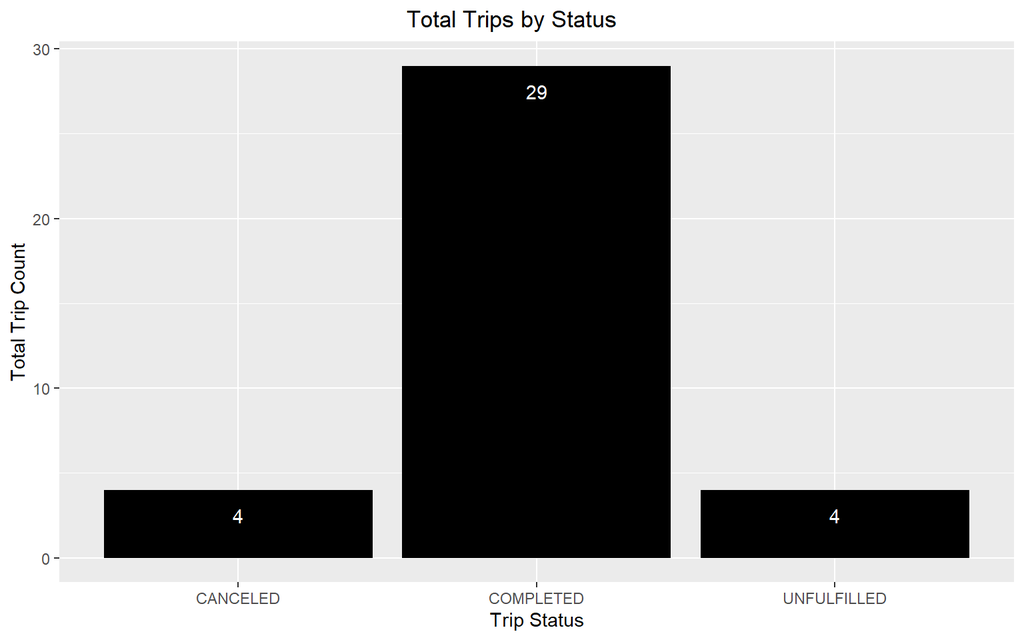

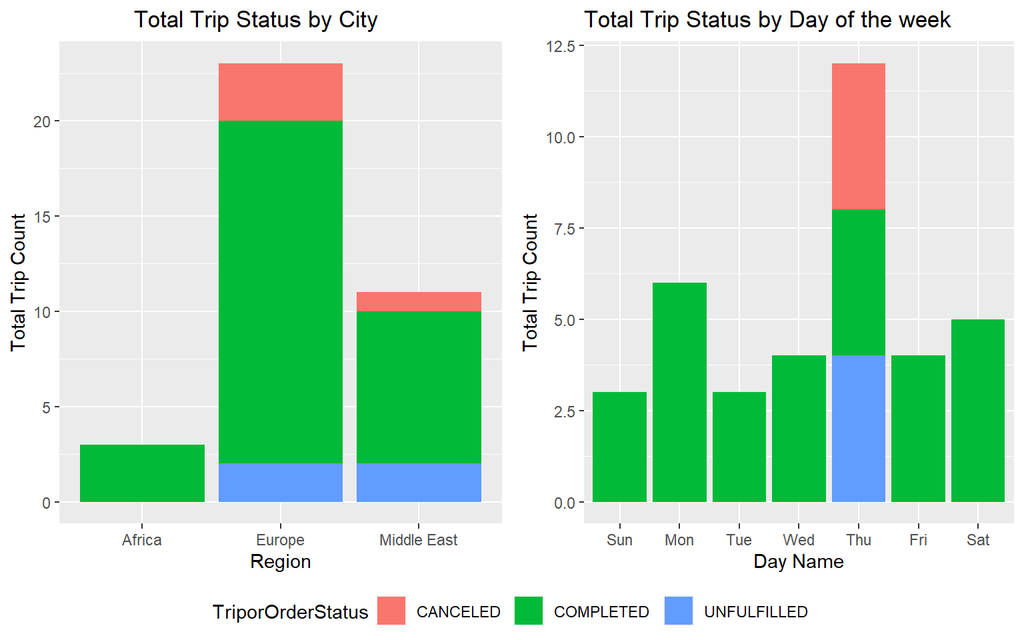

When looking at the time of day we can group the hours into categories and display it that way. This helps reduce the complexity for the viewer and often proves more user-friendly when posing such problems to predictive models where the inference of the model parameters are important.

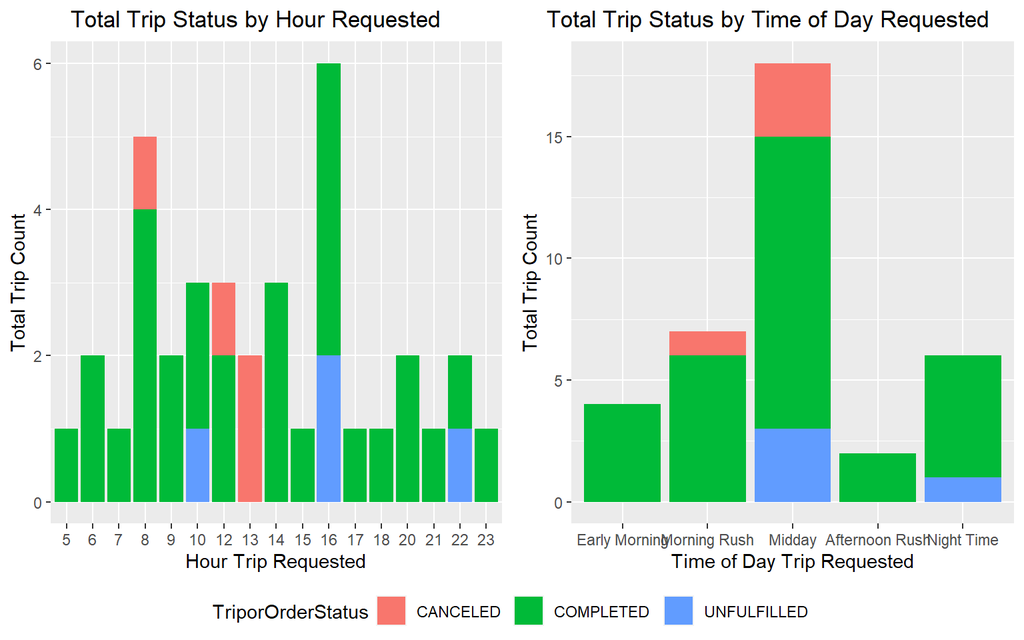

### Success Rates:

One of my favourite ways to look at a binary variable is by drawing heatmaps. It often gives a nice way to interpret the results of a classification model too. Some additional data manipulation is required for this;

- First lets label all the unsuccessful trips with a 1, and all successful trips with a 0
- Then we can summarise over the more insightful variables

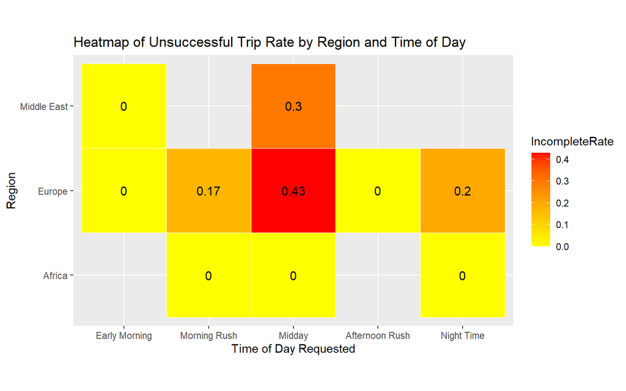

```r
#Create a binary value for the success or cancellation of a trip
Alldata$OrderIncomplete<- case_when (Alldata$TriporOrderStatus == "COMPLETED" ~ 0,
                                     TRUE ~ 1)

#summarise Alldata into sad1:
sad1<-Alldata %>% group_by (City,  TimeofDayRequested) %>%
  summarize(IncompleteRate=round(mean(OrderIncomplete),2)
  )

#Heat map of sorts...
ggplot(sad1, aes(x = TimeofDayRequested, y = City, fill = IncompleteRate)) +
  geom_tile(color = "white") +
  scale_fill_gradient(low =  "yellow",
                      high = "red") +
  labs(x="Time of Day Requested", y= "Region")+
  geom_text(aes(label = IncompleteRate), color = "black", size = 4) +
  ggtitle("Heatmap of Unsuccessful Trip Rate by Region and Time of Day")+
  coord_fixed()
```

In the same way we get the following heatmap …

The values inside the tiles can be interpreted as a percentage of trips which are not completed for these pockets of data, for example for all trips in Europe on a Thursday 71% of my trips were not completed successfully

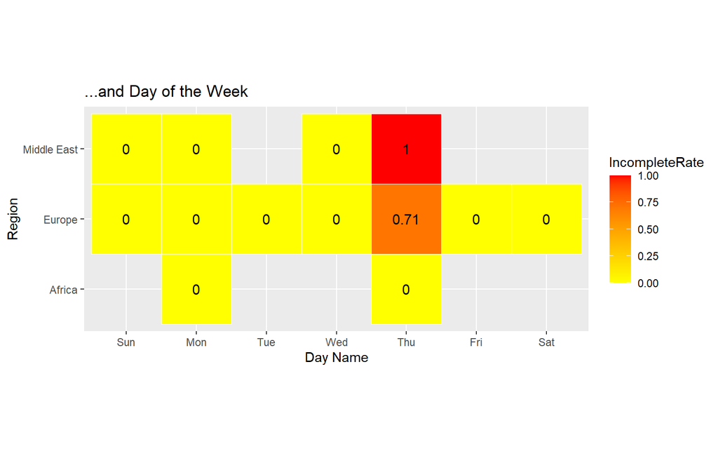

*Never get an Uber on a Thursday…. when you’re me*

### Pricing:

*In this section we only look at successful trips*

After converting all the trips into US$ amounts and the distance into the metric system, I had a look at how the trips compared in price

**Caveat: if we really want to make this a fair analysis then obviously we would need to include purchasing power parity, convert the amounts to real terms by looking at inflation and more, however for the purposes of this quick analysis I just wanted to compare the amounts**

From the boxplots you see that the price per Kilometer is noticeably higher in Europe than the other two regions, with two specific outliers:

- One is for a very short trip
- The other was due to a surcharge

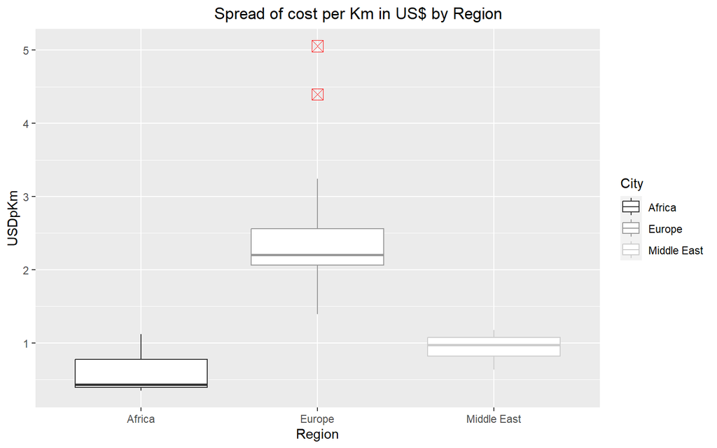

#### The outliers:

One would theorize that the first few Kilometers would be more expensive and after covering some fixed costs, some economies of scale would set in to drop the cost per Km and start to stabilize. Perhaps the costs would increase again the further the trip takes the driver from their hub.

Fitting a simple linear regression through the data points shows there is a negative correlation between distance and price per km as expected, for all except Africa. This may be due to the relatively large distances traveled or an anomaly caused by low exposure. The fat confidence intervals show that there is definitely more factors that contribute to this

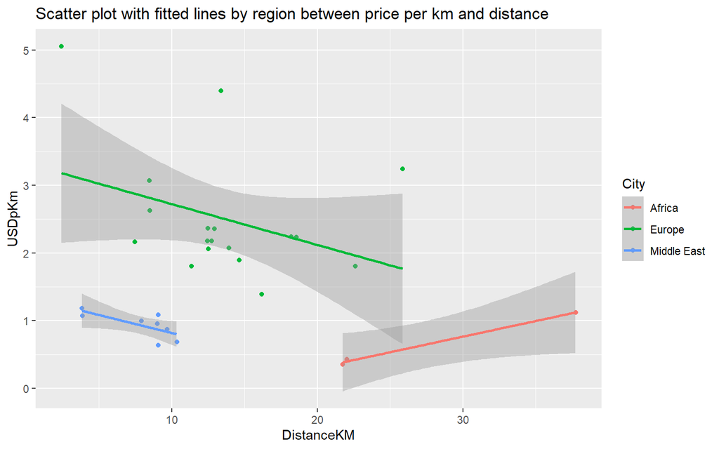

To understand the surcharge one would need more than a single clients trips. However there is definitely a correlation between time of day and price as well as the day of the week. When comparing the various regions it would be advisable to standardise the weekdays as the weekends do not fall on the same day for the middle east and Europe for example

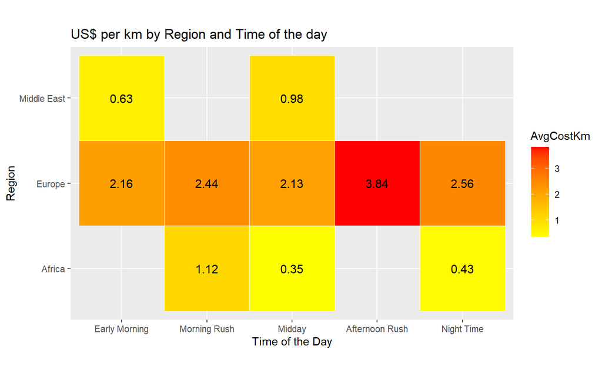

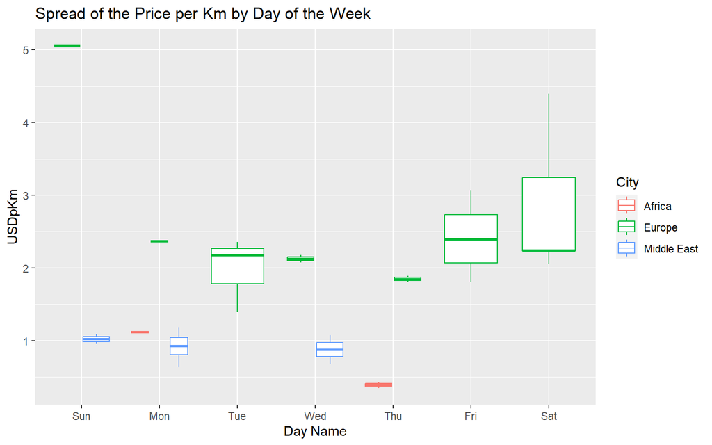

## Conclusion:

I enjoy trying to figure out what companies know about me, and this was really just a self indulgent exercise to do exactly that. When looking at your own data you can often understand an otherwise unknown data set a bit better.

It would be interesting to see if the Kaggle taxi data set could help build out the theories on cost per km and check how accurately we can predict what the cost would be.

But until then … I’m hailing a yellow cab if its a Thursday!